# Cereal Market

## 3.2 Uni-variate Graphical

### 3.2.1 Categorical/Factor variables

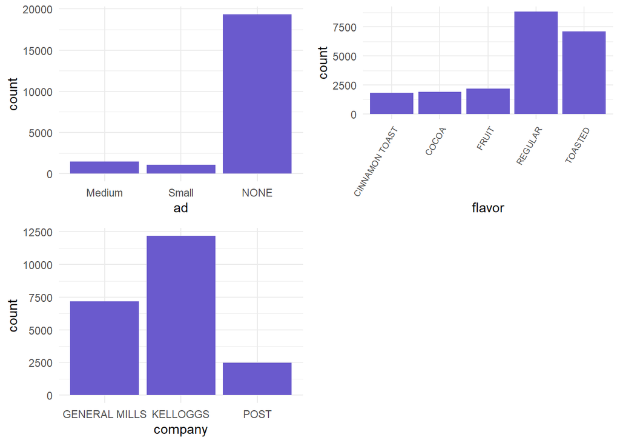

```r
# Use histograms to graph categorical variables
grid.arrange(
  ggplot(data = mtp, mapping = aes(x = ad)) +
  geom_bar(fill = 'slateblue')+
  theme_minimal(),
  ggplot(data = mtp, mapping = aes(x = flavor)) +
  geom_bar(fill = 'slateblue')+
  theme_minimal() +
  theme(axis.text.x = element_text(angle = 60, hjust = 1, size = 7)),

  ggplot(data = mtp, mapping = aes(x = company)) +
  geom_bar(fill = 'slateblue')+
  theme_minimal(),
ncol = 2)
```

- Most of the sales in the dataset have no ad
  - There are more medium ads than small
- Regular is the most popular flavor, followed by Toasted
- Kelloggs has the most frequent transactions, since the graph does not necessarily tell how many units were sold.

### 3.2.2 Quantitative variables

#### 3.2.2.1 Price and Volume

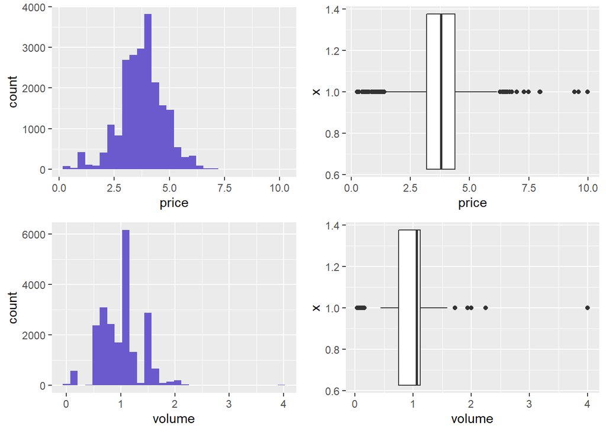

```r
grid.arrange(
  ggplot(data = mtp, mapping = aes(x = price)) +
  geom_histogram(fill = "slateblue"),
  ggplot(data = mtp, mapping = aes(x = 1)) +
  geom_boxplot(mapping = aes(y = price)) +
  coord_flip(),

  ggplot(data = mtp, mapping = aes(x = volume)) +
  geom_histogram(fill = "slateblue"),
  ggplot(data = mtp, mapping = aes(x = 1)) +
  geom_boxplot(mapping = aes(y= volume)) +
  coord_flip()
)
```

- Comments:
  - Price seems more normally distributed than volume
    - Wonder what sort of packages are selling at such a high price.
  - Most of volume runs at around 1.